# Peer Graded Assignment: Course Project 1

Douglas Weatherhead

September 13, 2016

## Loading and preprocessing the data

Here we will load the raw data and ensure the formats are correct, Dates are Dates and numbers are numbers.

```r
### Read activity data into a dataframe
data_raw <- read.csv("activity.csv")

# Convert to Date format
data_raw$date <- as.Date(data_raw$date)
# Convert Steps to numeric format
data_raw$steps <- as.numeric(data_raw$steps)
```

## What is mean total number of steps taken per day?

Lets take a look at how many steps are taken on average!

1. Make a histogram of the total number of steps taken each day
2. Calculate and report the mean and median total number of steps taken per day

```r
## We'll first need to load a package to help wrangle the data.
library("dplyr", warn.conflicts = FALSE)
```

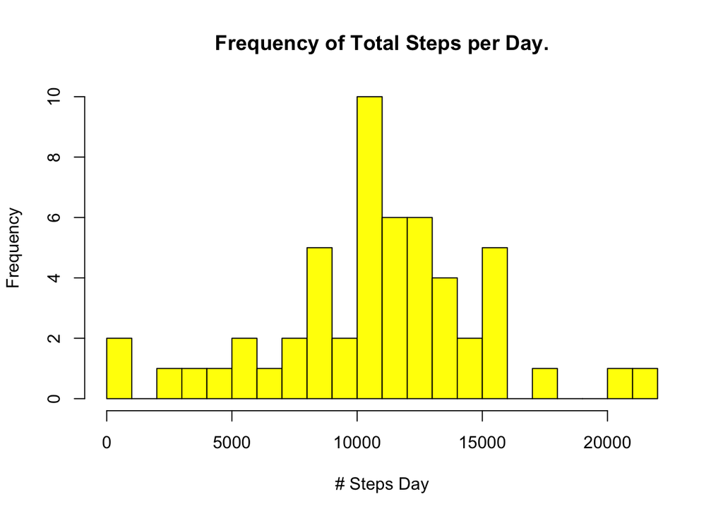

```r
# Remove NAs from dataset to determine steps taken each day!
data <- na.omit(data_raw)

## Data Wrangle Processed Data Set
stepsperday <- data %>%
    group_by(date) %>%
    summarize(TotalSteps=sum(steps))

## Plot Histogram of total steps per day
hist(stepsperday$TotalSteps,
     breaks = 20,
     xlab = "# Steps Day",
     main = "Frequency of Total Steps per Day.",
     col = 7)
```

```r
## Find AVERAGE Steps Per Date
mean_steps <- mean(stepsperday$TotalSteps)

## Find MEDIAN Steps Per Date
median_steps <- median(stepsperday$TotalSteps)
```

The *average* steps per a day is: 10766.19 … and the *median* steps per a day is 10765.

## What is the average daily activity pattern?

1. Make a time series plot (i.e. type = “l”) of the 5-minute interval (x-axis) and the average number of steps taken, averaged across all days (y-axis)
2. Which 5-minute interval, on average across all the days in the dataset, contains the maximum number of steps?

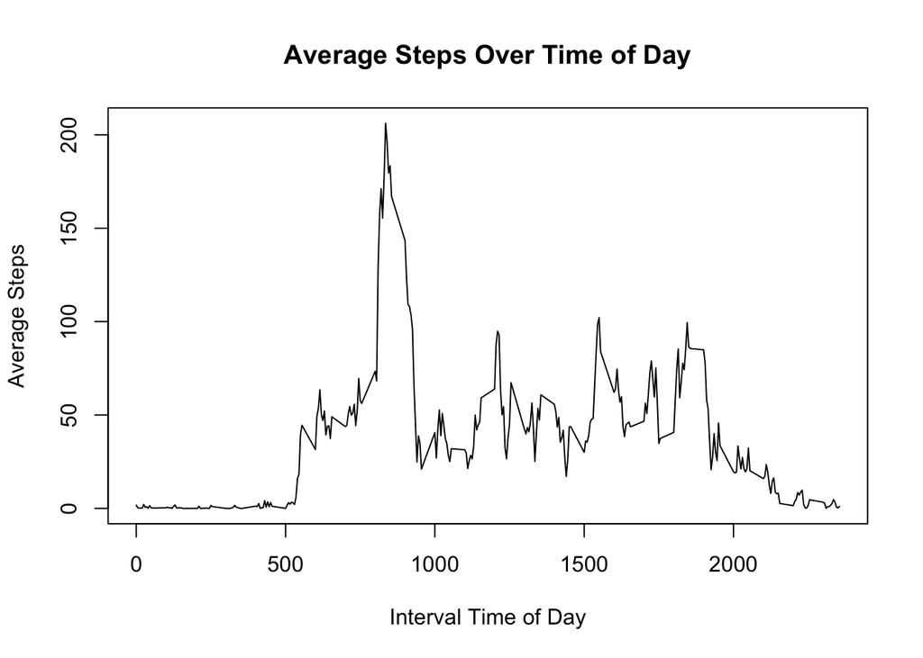

```r
# Group data by 5 minute interval and summarize the average
# number of steps in that interval
interval_average <- data %>%
    group_by(interval) %>%
    summarize(AverageSteps=mean(steps))

plot( x = interval_average$interval, y = interval_average$AverageSteps,
      type = "l",
      xlab = "Interval Time of Day",
      ylab = "Average Steps",
      main = "Average Steps Over Time of Day")
```

```r
## Find the Peak Steps interval time
peak_interval <- interval_average$interval[which.max(interval_average$AverageSteps)]
```

The 5-minute interval with the most average steps is 835

# Imputing missing values

Lets find out how many missing values are in the steps column of the data_raw DF

```r
### How many missing values are in the steps column of the data_raw DF
num_NA <- sum(is.na(data_raw$steps))
```

2304 records are missing values and are labelled “NA”“.

We can now impute values into the missing values, for this example we will use the average steps for all intervals

```r
###Impute NA Values as the average steps for all intervals
### First find the average steps per interval
average_interval_steps <- mean(interval_average$AverageSteps)

## Now impute this average into the missing NA's
data_raw$steps[is.na(data_raw$steps)] <- average_interval_steps

### Check to see if the NA's have been imputed
### Find how many missing values are in the steps column of the data_raw DF
num_NA <- sum(is.na(data_raw$steps))
```

Now 0 records are missing values and are “NA”.

Lets plot the new imputed dataset and see the differences compared to the raw data set.

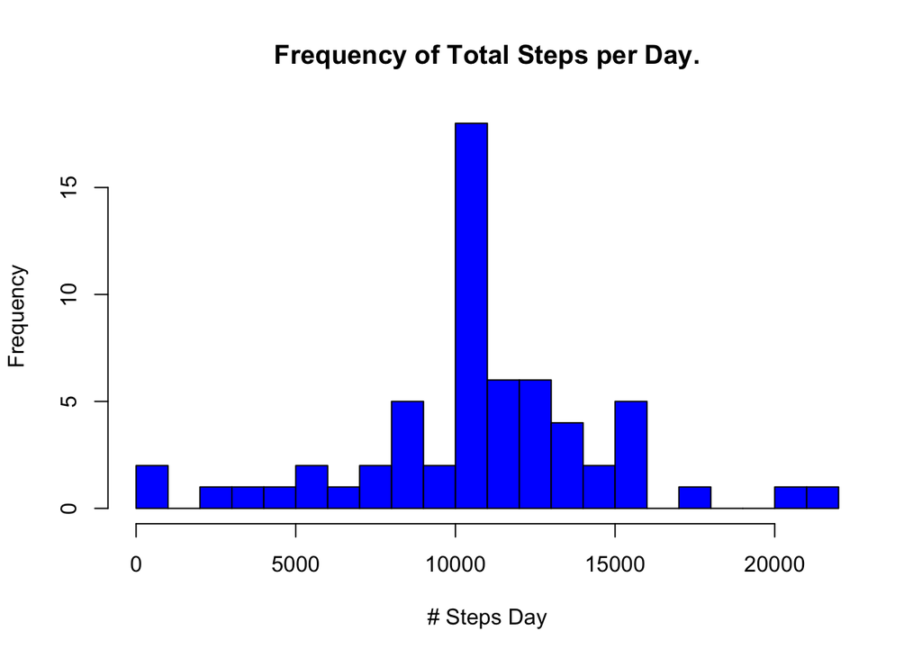

```r
## Data Wrangle imputed Data Set
stepsperday <- data_raw %>%
    group_by(date) %>%
    summarize(TotalSteps=sum(steps))

## Plot Histogram of total steps per day with the imputed data
hist(stepsperday$TotalSteps,
     breaks = 20,
     xlab = "# Steps Day",
     main = "Frequency of Total Steps per Day.",
     col = 4)
```

```r
## Find AVERAGE Steps Per Date of imputed dataset
mean_steps_impute <- mean(stepsperday$TotalSteps)

## Find MEDIAN Steps Per Date of imputed dataset
median_steps_impute <- median(stepsperday$TotalSteps)
```

#### Differences Between Raw Data and Imputed Data

The *average* steps per a day with imputed data is: 10766.19 … and the *median* steps per a day with imputed data is 10766.19.

The **Difference** in *average* steps between the two datasets (imputed and removed ‘NA’ Values) is 0

The **Difference** in *median* steps between the two datasets (imputed and removed ‘NA’ Values) is 1.1886792

*From a mean and median perspective little absolute differences are realized by imputing the values.*

# Are there differences in activity patterns between weekdays and weekends?

Lets consider differences between weekdays and weekends. First we’ll need to define a new feature variable and then plot the results.

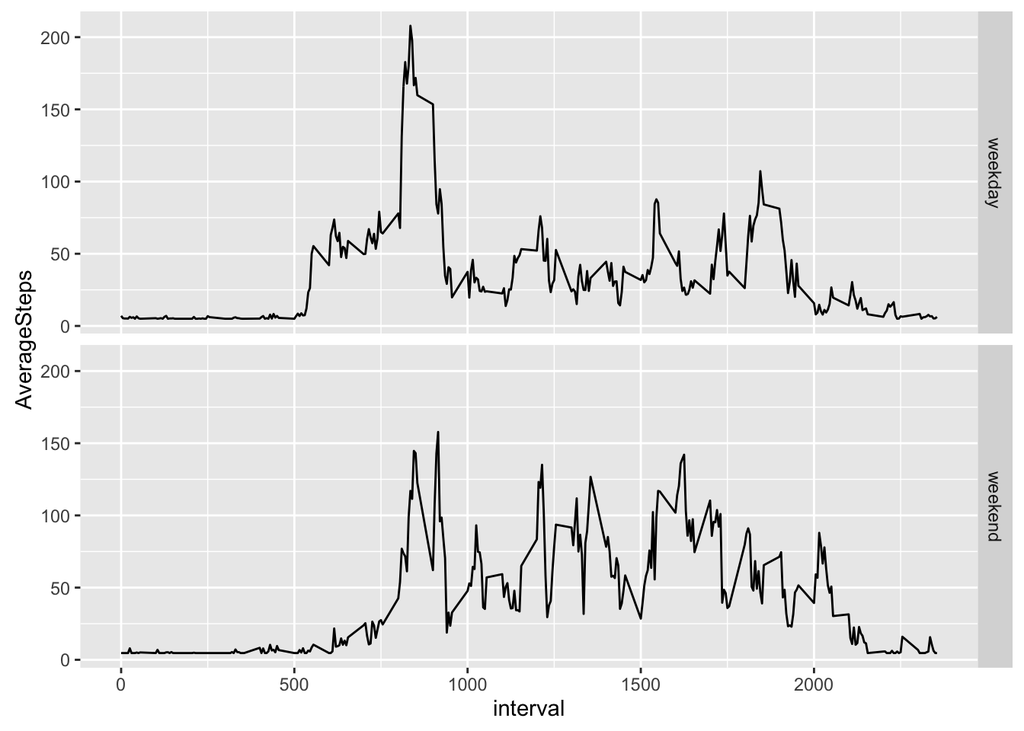

```r
## Make a feature variable with each date's corresponding Day
data_raw$day <- weekdays(data_raw$date)

## Make all day's weekday and then change Sat / Sun to Weekend
data_raw$weekend <- "weekday"
data_raw$weekend[data_raw$day %in% c("Saturday", "Sunday")] <- "weekend"

## Subset and group data by weekend/weekday and interval time finding the average steps for this group segmentation.
weekend_average <- data_raw %>%
    group_by(weekend, interval) %>%
    summarize(AverageSteps=mean(steps))

## Create Multi Panel Plot
## Load ggplot2
library(ggplot2)
## Plot the average steps vs interval , one panel Weekday - another Weekend.
qplot(x =  interval,
      y = AverageSteps,
      data = weekend_average,
      geom = "line",
      facets = weekend ~ .)
```

#### As we could hypothesis, there are differences in step activity between weekdays and weekends!